# Third Week: Exploratory Data Analysis

LaLiga Analysis

Mobin-Asri

February 28, 2018

# تمرین سری سوم: از لالیگا تا لیگ برتر

> با استفاده از داده های لیگ دسته اول اسپانیا به سوالات زیر پاسخ دهید. از هر دو ابزار ggplot2 و highcharter برای این کار تصویرسازی استفاده نمایید.

```r
library(engsoccerdata)
library(dplyr)
library(ggplot2)
library(highcharter)

#########
data("spain")
#########
```

۱. تعداد قهرمانی های تیم ها در تاریخ لالیگا را استخراج کرده و نمودار ستونی آنها را رسم کنید.

در ابتدا جدول انتهای فصل تمام سال ها را تشکیل می دهیم.

```r
rbind(
  spain %>%
    select(Season, team = home, opp = visitor, GF = hgoal, GA = vgoal),
  spain %>%
    select(Season, team = visitor, opp = home, GF = vgoal, GA = hgoal)
) %>% mutate(GD = GF-GA) %>%
  group_by(team,Season) %>%
  summarize(GP = n(),
            goalsF = sum(GF),
            goalsA = sum(GA),
            goaldif = sum(GD),
            W = sum(GD>0),
            D = sum(GD==0),
            L = sum(GD<0)
  ) %>%
  mutate(score = W*3 + D) %>%
  group_by(Season) %>%
  mutate(rank = order(order(-score,-goaldif,-goalsF))) %>%
  arrange(Season) -> ltable
```

```r
head(ltable)
```

```
## # A tibble: 6 x 11
## # Groups:   Season [1]
##                 team Season    GP goalsF goalsA goaldif     W     D     L
##                <chr>  <dbl> <int>  <dbl>  <dbl>   <dbl> <int> <int> <int>
## 1    Arenas de Getxo   1928    18     32     39      -7     8     3     7
## 2    Athletic Bilbao   1928    18     43     33      10     8     4     6
## 3    Atletico Madrid   1928    18     43     41       2     8     2     8
## 4          CE Europa   1928    18     45     49      -4     6     4     8
## 5 Espanyol Barcelona   1928    18     32     38      -6     7     4     7
## 6       FC Barcelona   1928    18     37     23      14    11     3     4
## # ... with 2 more variables: score <dbl>, rank <int>
```

قهرمان هر سال را جدا می کنیم.

```r
ltable %>% ungroup() %>%
  filter(rank==1) -> Champions
```

هیستوگرام دفعات قهرمانی برای تیم های مختلف را رسم می کنیم.

```r
table=count(Champions,team) %>%  arrange(n)

hchart(table,hcaes(x=team,y=n),type="bar",color="green") %>%
  hc_add_theme(hc_theme_sandsignika())
```

[interactive chart not shown]

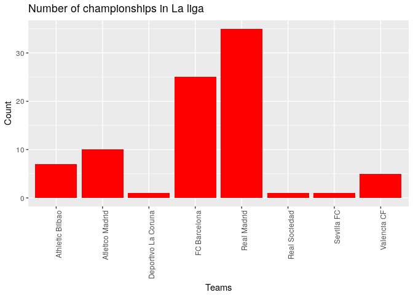

```r
ggplot(Champions,aes(x=team)) + geom_histogram(stat="count",fill="red") +
  theme(axis.text.x = element_text(angle = 90, hjust = 1)) + xlab("Teams") + ylab("Count") +
  ggtitle("Number of championships in La liga")
```

***

۲. کسل کننده ترین لیگ و تیم را بیابید. نمودار ده تیم و ده فصل کسل کننده را رسم کنید.

هر چه میانگین تعداد گل های به ثبت رسیده در هر بازی کمتر باشد آن فصل یا آن تیم کسل کننده تر است.

```r
ltable %>%
  group_by(Season) %>%
  summarise(totGoals=(sum(goalsF)/sum(GP/2))) %>%
  arrange(totGoals) %>%
  slice(1:10) -> Boring_Seasons
```

در سال 1972 به طور متوسط در هر بازی 2.14 گل به ثبت رسیده که در تاریخ لالیگا کمترین مقدار خود را دارد.

```r
head(Boring_Seasons)
```

```
## # A tibble: 6 x 2
##   Season totGoals
##    <dbl>    <dbl>
## 1   1972 2.143791
## 2   1990 2.163158
## 3   1984 2.163399
## 4   1971 2.205882
## 5   1970 2.262500
## 6   1988 2.284211
```

```r
Boring_Seasons$Season=as.character(Boring_Seasons$Season)
Boring_Seasons %>% arrange(totGoals) -> Boring_Seasons

hchart(Boring_Seasons,hcaes(x=Season,y=totGoals),type="bar")
```

[interactive chart not shown]

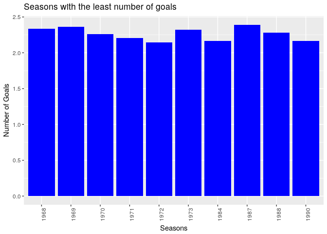

```r
ggplot(Boring_Seasons)+geom_bar(aes(x=Season,y=totGoals),
                                stat="identity",fill="blue")+
  theme(axis.text.x = element_text(angle = 90, hjust = 1))+
  xlab("Seasons") + ylab("Number of Goals") +
  ggtitle("Seasons with the least number of goals")
```

```r
ltable %>%
  group_by(team) %>%
  summarise(totGoals=(sum(goalsF)/sum(GP))) %>%
  arrange(totGoals) %>%
  slice(1:10) -> Boring_teams
```

تیم CF Extremadura به طور متوسط در هر بازی 0.77 گل به ثبت رسانده است که در بین تیم های لالیگا کمترین مقدار را دارد.

```r
head(Boring_teams)
```

```
## # A tibble: 6 x 2
##             team  totGoals
##            <chr>     <dbl>
## 1 CF Extremadura 0.7750000
## 2    CD Logrones 0.8410405
## 3      CP Merida 0.8750000
## 4       Cadiz CF 0.8766816
## 5    Real Burgos 0.8859649
## 6  Pontevedra CF 0.9166667
```

```r
hchart(Boring_teams,hcaes(x=team,y=totGoals),type="bar") %>%
  hc_add_theme(hc_theme_tufte2())  %>%
  hc_title(text = "Teams with the least number of goals")
```

[interactive chart not shown]

۳. در چند درصد موارد قهرمان نیم فصل در پایان فصل قهرمان شده است؟

بازی های مربوط به نیم فصل دوم را حذف می کنیم.

```r
rbind(
  spain %>%
    select(Date,Season, team = home, opp = visitor, GF = hgoal, GA = vgoal),
  spain %>%
    select(Date,Season, team = visitor, opp = home, GF = vgoal, GA = hgoal)
) %>%
  group_by(team,Season) %>%
  arrange(Date) %>%
  mutate(Week = seq(n())) -> WeekbyWeek

WeekbyWeek  %>%
  group_by(team,Season) %>%
  filter(Week <= (n()/2)) -> HalfSeason
```

جدول پایان نیم فصل ها را تشکیل می دهیم.

```r
HalfSeason %>%
  mutate(GD = GF-GA) %>%
  group_by(team,Season) %>%
  summarize(GP = n(),
            goalsF = sum(GF),
            goalsA = sum(GA),
            goaldif = sum(GD),
            W = sum(GD>0),
            D = sum(GD==0),
            L = sum(GD<0)
  ) %>%
  mutate(score = W*3 + D) %>%
  group_by(Season) %>%
  mutate(rank = order(order(-score,-goaldif,-goalsF))) %>%
  arrange(Season) -> ltable_half
```

```r
head(ltable_half)
```

```
## # A tibble: 6 x 11
## # Groups:   Season [1]
##                 team Season    GP goalsF goalsA goaldif     W     D     L
##                <chr>  <dbl> <int>  <dbl>  <dbl>   <dbl> <int> <int> <int>
## 1    Arenas de Getxo   1928     9     18     15       3     5     2     2
## 2    Athletic Bilbao   1928     9     28     16      12     5     1     3
## 3    Atletico Madrid   1928     9     19     19       0     4     0     5
## 4          CE Europa   1928     9     21     27      -6     3     1     5
## 5 Espanyol Barcelona   1928     9     18     18       0     5     1     3
## 6       FC Barcelona   1928     9     15     19      -4     4     1     4
## # ... with 2 more variables: score <dbl>, rank <int>
```

```r
ltable_half %>%
  filter(rank==1)  -> Champions_half

sum(Champions_half$team == Champions$team)/nrow(Champions)
```

```
## [1] 0.5176471
```

۴. در بین سال های ۲۰۰۱ تا ۲۰۱۰ گربه سیاه تیم های بزرگ چه تیم هایی بوده است؟

می خواهیم گربه سیاه دو تیم بارسلونا و ریال مادرید را پیدا کنیم.

معیار برای گربه سیاه بودن آن است با تعداد بازی کم بیشترین امتیاز را از تیم موردنظر گرفته باشد.

```r
spain %>% filter(Season <= 2010 & Season >= 2001) -> case

rbind(
  case %>%
    select(Date,Season, team = home, opp = visitor, GF = hgoal, GA = vgoal),
  case %>%
    select(Date,Season, team = visitor, opp = home, GF = vgoal, GA = hgoal)
) %>%
  mutate(GD = GF - GA) -> stat
```

تیم اتلتیکو مادرید با 18 بازی رو در رو با تیم بارسلونا به تعداد 7 بار آن را شکست داده و 4 بار نتیجه را به مساوی کشانده است.

```r
stat %>%
  filter(team == "FC Barcelona" )  -> Winners

Winners %>%
  group_by(opp) %>%
  summarise(W = sum(GD < 0), D= sum(GD == 0) , Plays= n() ) %>%
  arrange(-W,-D) -> BlackCats

BlackCats %>% slice(1:10)
```

```
## # A tibble: 10 x 4
##                    opp     W     D Plays
##                  <chr> <int> <int> <int>
##  1     Atletico Madrid     7     4    18
##  2         Real Madrid     6     6    20
##  3       Villarreal CF     6     4    20
##  4         Valencia CF     5     6    20
##  5 Deportivo La Coruna     5     4    20
##  6          Real Betis     4     5    16
##  7          CA Osasuna     3     7    20
##  8  Espanyol Barcelona     3     5    20
##  9          Sevilla FC     3     4    20
## 10          Celta Vigo     3     2    10
```

```r
ltable %>% filter(Season <= 2010 & Season >= 2001 &
                    team=="Atletico Madrid") %>%
  select(rank)
```

```
## # A tibble: 9 x 2
## # Groups:   Season [9]
##   Season  rank
##    <dbl> <int>
## 1   2002    11
## 2   2003     7
## 3   2004    11
## 4   2005    10
## 5   2006     7
## 6   2007     5
## 7   2008     4
## 8   2009     9
## 9   2010     5
```

تیم Deportivo La Coruna با 20 بازی رودررو با تیم ریال مادرید به تعداد 8 بار آن را شکست داده و 2 بار نتیجه را به مساوی کشانده است.

```r
stat %>%
  filter(team == "Real Madrid" )  -> Winners

Winners %>%
  group_by(opp) %>%
  summarise(W = sum(GD < 0), D= sum(GD == 0) , Plays= n() ) %>%
  arrange(-W,-D) -> BlackCats

BlackCats %>% slice(1:10)
```

```
## # A tibble: 10 x 4
##                    opp     W     D Plays
##                  <chr> <int> <int> <int>
##  1        FC Barcelona     8     6    20
##  2 Deportivo La Coruna     8     2    20
##  3          Sevilla FC     7     1    20
##  4          CA Osasuna     5     3    20
##  5         Valencia CF     5     3    20
##  6     Athletic Bilbao     5     1    20
##  7        RCD Mallorca     4     4    20
##  8       Real Sociedad     4     3    14
##  9  Espanyol Barcelona     4     2    20
## 10           Getafe CF     4     2    14
```

ضعف تیم Deportivo La Coruna در نیمه ی دوم این دهه نشان دهنده ی آن است که گزینه ی مناسبی برای گربه سیاه تیم ریال مادرید است.

```r
ltable %>% filter(Season <= 2010 & Season >= 2001 &
                    team=="Deportivo La Coruna") %>%
  select(rank)
```

```
## # A tibble: 10 x 2
## # Groups:   Season [10]
##    Season  rank
##     <dbl> <int>
##  1   2001     2
##  2   2002     3
##  3   2003     3
##  4   2004     9
##  5   2005     8
##  6   2006    13
##  7   2007     8
##  8   2008     7
##  9   2009    10
## 10   2010    18
```

۵. در تاریخ لالیگا کدام تیم رکورددار زودترین قهرمانی است؟ همچنین کدام تیم مقتدرانه ترین قهرمانی را داشته است؟

قهرمانی زود هنگام زمانی رقم می خورد که اختلاف امتیاز تیم اول و تیم دوم به حدی زیاد باشد که با فرض برد تمام بازی های تیم دوم و باخت تمام بازی های تیم اول نیز رتبه اول تغییر نکند.

رتبه و امتیاز تمام تیم ها در تمام هفته ها محاسبه می شود.

در ستون notPlayed تعداد بازی های پیشرو ذخیره شده است.

```r
rbind(
  spain %>%
    select(Season,Date, team = home, opp = visitor, GF = hgoal , GA = vgoal),
  spain %>%
    select(Season,Date, team = visitor, opp = home, GF = vgoal , GA = hgoal)
) %>% mutate(GD = GF - GA) %>%
  group_by(Season,team) %>%
  arrange(Date) %>%
  mutate(GP=n(),
         goalsF= cumsum(GF),
         goalsA= cumsum(GA),
         goaldif= cumsum(GD),
         W = cumsum(GD > 0),
         D = cumsum(GD == 0),
         L = cumsum(GD < 0)
  ) %>%
  mutate(Score = 3*W + D) %>%
  ungroup()-> WeekbyWeekScore

WeekbyWeekScore %>%
  group_by(Season,team) %>%
  mutate(notPlayed = seq((n()-1),0)) %>%
  group_by(Season,notPlayed) %>%
  mutate(rank=(order(order(-Score,-goaldif,-goalsF)))) -> WeekbyWeekRank
```

زودترین قهرمانی ها متعلق به تیم های بارسلونا و ریال مادرید است که ۵ هفته زودتر از پایان فصل قطعی شده است.

```r
WeekbyWeekRank %>%
  group_by(Season,notPlayed) %>%
  summarise(team = team[rank==1] ,
            Dif=(Score[rank==1]-Score[rank==2])) -> Difstat

Difstat %>% ungroup() %>%
  filter(Dif > 3 * (notPlayed) & notPlayed >0)  %>%
  filter(notPlayed == max(notPlayed)) %>%
  arrange(-notPlayed) -> SoonChamp

SoonChamp
```

```
## # A tibble: 5 x 4
##   Season notPlayed         team   Dif
##    <dbl>     <int>        <chr> <dbl>
## 1   1960         5  Real Madrid    21
## 2   1962         5  Real Madrid    17
## 3   1973         5 FC Barcelona    16
## 4   1974         5  Real Madrid    16
## 5   1990         5 FC Barcelona    17
```

معیار برای اقتدار تفاضل امتیاز با تیم دوم جدول است.

مقتدرانه ترین قهرمانی متعلق به تیم ریال مادرید در سال 1962 می باشد.

```r
ltable %>%
  group_by(Season) %>%
  summarise(team=team[rank==1], Dif = score[rank==1] - score[rank==2]) %>%
  arrange(-Dif) %>%
  slice(1:10)
```

```
## # A tibble: 10 x 3
##    Season         team   Dif
##     <dbl>        <chr> <dbl>
##  1   1962  Real Madrid    21
##  2   1960  Real Madrid    19
##  3   1985  Real Madrid    19
##  4   1974  Real Madrid    17
##  5   1987  Real Madrid    17
##  6   1990 FC Barcelona    16
##  7   1984 FC Barcelona    15
##  8   2012 FC Barcelona    15
##  9   1989  Real Madrid    14
## 10   1968  Real Madrid    12
```

۶. طولانی ترین نوار پیروزی مساوی و شکست مال چه تیم هایی است؟

```r
spain=as.tbl(spain)

rbind(
  spain %>%
    select(Date,Season, team = home, opp = visitor, GF = hgoal , GA = vgoal),
  spain %>%
    select(Date,Season, team = visitor, opp = home, GF = vgoal , GA = hgoal)
) %>% mutate(GD = GF - GA) %>%
  group_by(Season,team) %>%
  arrange(Date) %>%
  mutate(W = GD > 0,
         D = GD == 0,
         L = GD < 0) %>%
  summarise(cons_W = rle(W)$lengths[rle(W)$values == TRUE] %>% max(),
            cons_D = rle(D)$lengths[rle(D)$values == TRUE] %>% max(),
            cons_L = rle(L)$lengths[rle(L)$values == TRUE] %>% max()
  ) %>%
  ungroup()-> Consecutive_Result
```

طولانی ترین نوار پیروزی مساوی و شکست برای تمام تیم ها محاسبه شده است.

```r
head(Consecutive_Result)
```

```
## # A tibble: 6 x 5
##   Season               team cons_W cons_D cons_L
##    <dbl>              <chr>  <int>  <dbl>  <dbl>
## 1   1928    Arenas de Getxo      6      2      3
## 2   1928    Athletic Bilbao      3      1      2
## 3   1928    Atletico Madrid      3      1      4
## 4   1928          CE Europa      2      2      2
## 5   1928 Espanyol Barcelona      2      2      2
## 6   1928       FC Barcelona      6      1      2
```

تیم بارسلونا با 16 برد پیاپی رکورد دار است.

```r
Consecutive_Result %>%
  arrange(desc(cons_W))  %>% select(Season,team,cons_W) %>%  slice(1:10) -> Top_Win

Top_Win
```

```
## # A tibble: 10 x 3
##    Season         team cons_W
##     <dbl>        <chr>  <int>
##  1   2010 FC Barcelona     16
##  2   1960  Real Madrid     15
##  3   2005 FC Barcelona     14
##  4   2009  Real Madrid     12
##  5   2012 FC Barcelona     12
##  6   2014  Real Madrid     12
##  7   2015 FC Barcelona     12
##  8   2015  Real Madrid     12
##  9   1962  Real Madrid     11
## 10   2011 FC Barcelona     11
```

تیم UD Las Palmas با 11 باخت پیاپی در یک فصل رکورد دار است.

```r
Consecutive_Result %>%
  arrange(desc(cons_L))  %>% select(Season,team,cons_L) %>%  slice(1:10) -> Top_Lose

Top_Lose
```

```
## # A tibble: 10 x 3
##    Season            team cons_L
##     <dbl>           <chr>  <dbl>
##  1   1959   UD Las Palmas     11
##  2   1950     CD Alcoyano     10
##  3   1953  Sporting Gijon     10
##  4   2014      Cordoba CF     10
##  5   1941   Real Sociedad      9
##  6   1996     CD Logrones      9
##  7   1934 Arenas de Getxo      8
##  8   1941     Hercules CF      8
##  9   1952   Real Zaragoza      8
## 10   1967      Sevilla FC      8
```

تیم Burgos CF با 7 مساوی پیاپی در یک فصل رکورددار است.

```r
Consecutive_Result %>%
  arrange(desc(cons_D))  %>% select(Season,team,cons_D) %>%  slice(1:10) -> Top_Draw

Top_Draw
```

```
## # A tibble: 10 x 3
##    Season            team cons_D
##     <dbl>           <chr>  <dbl>
##  1   1978       Burgos CF      7
##  2   1945     Valencia CF      6
##  3   1963      Sevilla FC      6
##  4   1974     Hercules CF      6
##  5   1974   Real Sociedad      6
##  6   1982  Sporting Gijon      6
##  7   1984 Athletic Bilbao      6
##  8   1984     Valencia CF      6
##  9   1990      CA Osasuna      6
## 10   1990    CD Castellon      6
```

۷. زودترین سقوط مال کدام تیم بوده است؟

```r
WeekbyWeekRank %>%
  group_by(Season,notPlayed) %>%
  summarise(team = team [rank == n()],
            Dif=(Score[rank==(n()-1)]-Score[rank==n()])) -> Difstat

Difstat %>%
  filter(Dif > 3 * (notPlayed) & notPlayed >0) %>%
  group_by(Season) %>%
  summarise(team=team[which.max(notPlayed)],notPlayed=max(notPlayed)) %>%
  arrange(-notPlayed) -> SoonFall
```

زودترین سقوط متعلق به تیم Sporting Gijon است که 7 هفته مانده به پایان فصل سقوط آن قطعی شد.

```r
SoonFall
```

```
## # A tibble: 46 x 3
##    Season             team notPlayed
##     <dbl>            <chr>     <dbl>
##  1   1997   Sporting Gijon         7
##  2   1981     CD Castellon         5
##  3   1976        CD Malaga         4
##  4   1988         Elche CF         4
##  5   2003      Real Murcia         4
##  6   1928 Racing Santander         3
##  7   1943       Celta Vigo         3
##  8   1958       Celta Vigo         3
##  9   1974      Real Murcia         3
## 10   1977         Cadiz CF         3
## # ... with 36 more rows
```

روند تغییر رتبه تیم ها در طول فصل ۱۹۹۸ رسم نمایید.

```r
WeekbyWeekScore %>%
  filter(Season == 1998) %>%
  group_by(team) %>%
  mutate(Played = seq(n())) %>%
  ungroup() %>% group_by(Played) %>% mutate(lastDate=max(Date))-> stat

stat %>% ungroup() %>%
  group_by(lastDate) %>%
  mutate(rank = order(order(-Score,-goaldif,-goalsF))) -> DatebyDateRank
```

```r
DatebyDateRank$lastDate=as.Date(DatebyDateRank$lastDate)
DatebyDateRank %>%
  hchart(type= "line",hcaes(x=lastDate,y=rank,group=team))
```

[interactive chart not shown]

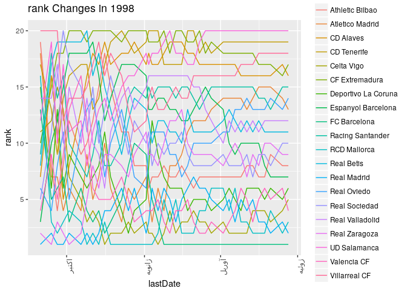

```r
ggplot(DatebyDateRank , aes(x=lastDate,y=rank,group=team,color=team)) +
  geom_line()+
  theme(axis.text.x = element_text(angle = 90, hjust = 1))+
  ggtitle("rank Changes in 1998")
```

۹. جدولی برای فصل ۲۰۱۲ از کل نتایج طراحی کنید.

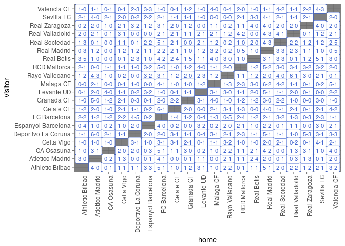

```r
spain %>%
  filter(Season == 2012) -> spain2012

season_matrix <- ggplot(spain2012,aes(x = home, y = visitor))+
  geom_label(aes(label=FT) ,color="royalblue3",size=3)
season_matrix +theme_dark()+ theme(axis.text.x = element_text(angle = 90, hjust = 1))
```

۱۰. سه آماره به همراه نمودار فردوسی پسند استخراج کنید.

آماره اول:

بیشترین پیشرفت یک تیم در دو فصل متوالی از نظر رتبه در جدول انتهای فصل

```r
ltable %>%
  group_by(team) %>%
  mutate(PreRank=c(-Inf,rank[-n()])) %>%
  mutate(Develope=PreRank-rank) %>%
  arrange(-Develope) %>%
  filter(PreRank <= 17) %>%
  select(team,Season,rank,PreRank,Develope) %>% ungroup() %>%
  slice(1:10)->stat
```

تیم Deportivo La Coruna با 14 رتبه پیشرفت در فصل 1992 در رتبه 3 قرار گرفت.

```r
head(stat)
```

```
## # A tibble: 6 x 5
##                  team Season  rank PreRank Develope
##                 <chr>  <dbl> <int>   <dbl>    <dbl>
## 1 Deportivo La Coruna   1992     3      17       14
## 2         Valencia CF   1988     3      16       13
## 3  Espanyol Barcelona   1966     3      15       12
## 4          Sevilla FC   1969     4      16       12
## 5     Atletico Madrid   1995     1      13       12
## 6  Espanyol Barcelona   2004     5      17       12
```

میزان پیشرفت تیم های با بیشترین میزان پیشرفت از نظر رتبه در دو فصل متوالی

```r
stat$teamSeason=paste(stat$team,stat$Season,sep=",")
hchart(stat,hcaes(x=teamSeason,y=Develope),type="column")
```

[interactive chart not shown]

آماره دوم:

بیشترین پس رفت یک تیم در دو فصل متوالی از نظر رتبه در جدول انتهای فصل

```r
ltable %>%
  group_by(team) %>%
  mutate(PreRank=c(Inf,rank[-n()])) %>%
  mutate(Decline=rank-PreRank) %>%
  arrange(-Decline) %>%
  filter(PreRank <= 17) %>%
  select(team,Season,rank,PreRank,Decline)%>% ungroup() %>%
  slice(1:10)->stat
```

تیم Celta Vigo در سال 2003 با 15 رتبه پسرفت نسبت به فصل قبل حضور خود در لالیگا در رتبه ی 19 قرار گرفت.

```r
head(stat)
```

```
## # A tibble: 6 x 5
##              team Season  rank PreRank Decline
##             <chr>  <dbl> <int>   <dbl>   <dbl>
## 1      Celta Vigo   2003    19       4      15
## 2   Villarreal CF   2011    18       4      14
## 3    RCD Mallorca   2001    16       3      13
## 4   Real Sociedad   2003    15       2      13
## 5      Real Betis   2013    20       7      13
## 6 Real Valladolid   1963    16       4      12
```

```r
stat$teamSeason=paste(stat$team,stat$Season,sep=",")
hchart(stat,hcaes(x=teamSeason,y=Decline),type="column")
```

[interactive chart not shown]

آماره سوم:

طولانی ترین نوار سال های متوالی که در آن سال ها قهرمانی فقط و فقط بین تیم های ریال مادرید و بارسلونا دست به دست می شد.

```r
ltable %>% ungroup() %>%
  filter(rank==1) %>%
  filter(team != "Real Madrid" & team != "FC Barcelona") %>%
  arrange(Season) %>%
  mutate(PreSeason=c(Inf,Season[-n()])) %>%
  mutate(DifSeason=Season-PreSeason)  %>%
  select(team,Season,PreSeason,DifSeason) %>%
  arrange(-DifSeason) %>%
  slice(1:10) -> ChampDif
```

بین سال های 1982 تا 1995 که مدت 13 سال است قهرمانی بین بارسلونا و ریال مادرید دست به دست می شد.

```r
head(ChampDif)
```

```
## # A tibble: 6 x 4
##              team Season PreSeason DifSeason
##             <chr>  <dbl>     <dbl>     <dbl>
## 1 Atletico Madrid   1995      1982        13
## 2 Atletico Madrid   1965      1955        10
## 3 Atletico Madrid   2013      2003        10
## 4 Athletic Bilbao   1955      1950         5
## 5   Real Sociedad   1981      1976         5
## 6 Atletico Madrid   1939      1935         4
```

```r
ChampDif$to_from=paste(ChampDif$PreSeason,ChampDif$Season,sep="-")
hchart(ChampDif,hcaes(x=to_from,y=DifSeason),type="column")
```

[interactive chart not shown]